# BOO 2025 - Example Analysis

## 2.5 PCA plot

**Exercise 10: Make a plot of two important PCs against each other, coloured by a relevant factor:**

**Hint**

You can use different shapes to visualize multiple factors in the same plot.

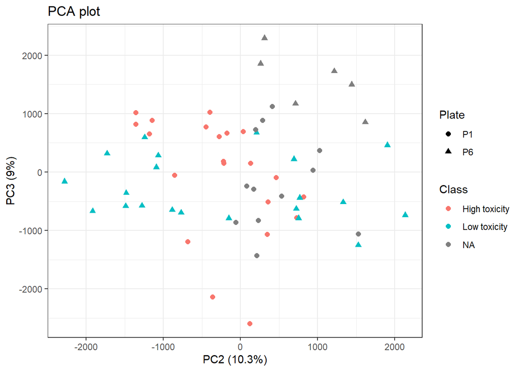

```r
metaData %>%
  # Plot PC2 against PC3
  ggplot(aes(x = PC2, y = PC3,
             # Coloured by compound class and with different shapes for each plate
             color = compound_class, shape=plate_ID)) +
  geom_point(size = 2) +
  # Set labels
  labs(x = paste0("PC2 (", round(100*var_explained[2,2], 2), "%)"),
       y = paste0("PC3 (", round(100*var_explained[3,2], 2), "%)"),
       color = "Class", shape = "Plate") +
  ggtitle("PCA plot") +
  theme_bw()
```

```r
# The PCA plot effectively shows that the type of compound used is the biggest driver of gene expression differences in your data (captured by PC1). PC2 captures additional, smaller variations, potentially linked to dose responses. The controls group as expected.
```

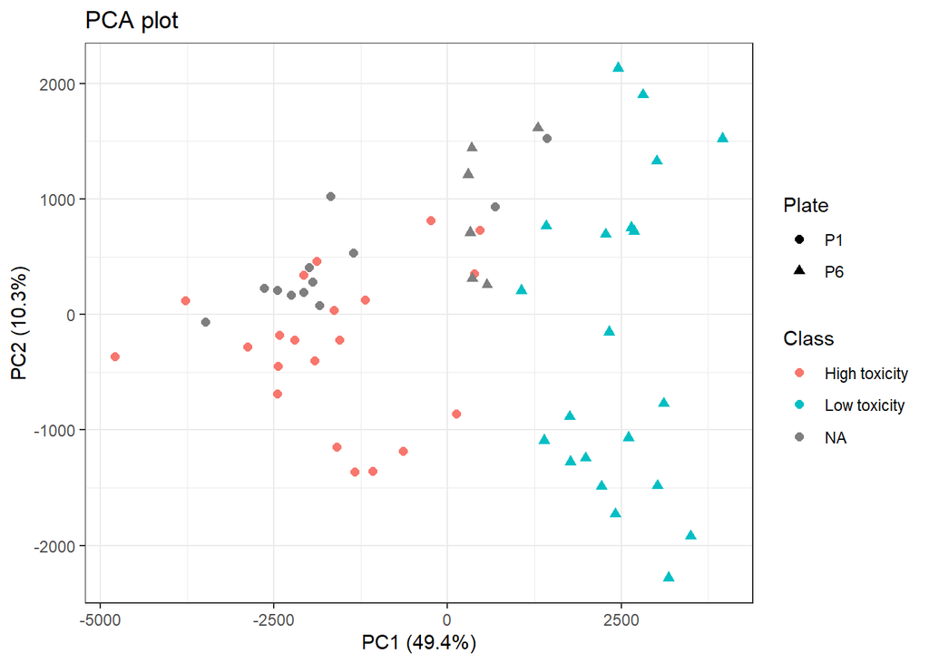

```r
# In Exercise 10 of Script 4, within the ggplot call:

metaData %>%
  ggplot(aes(x = PC1, y = PC2,
             # Coloured by compound class and with different shapes for each plate
             color = compound_class, shape=plate_ID)) +
  geom_point(size = 2) +
  # Set labels
   labs(x = paste0("PC1 (", round(100*var_explained[1,2], 2), "%)"),
        y = paste0("PC2 (", round(100*var_explained[2,2], 2), "%)"),
       color = "Class", shape = "Plate") +
  ggtitle("PCA plot") +
  theme_bw()
```

# 3 Advanced questions

Sometimes a PCA plot can highlight important clusters in your data. Gene loadings can be used to assess which gene’s expression is driving these clusters.

**Exercise 11: Investigate a pattern in your data and identify what genes are responsible for it:**

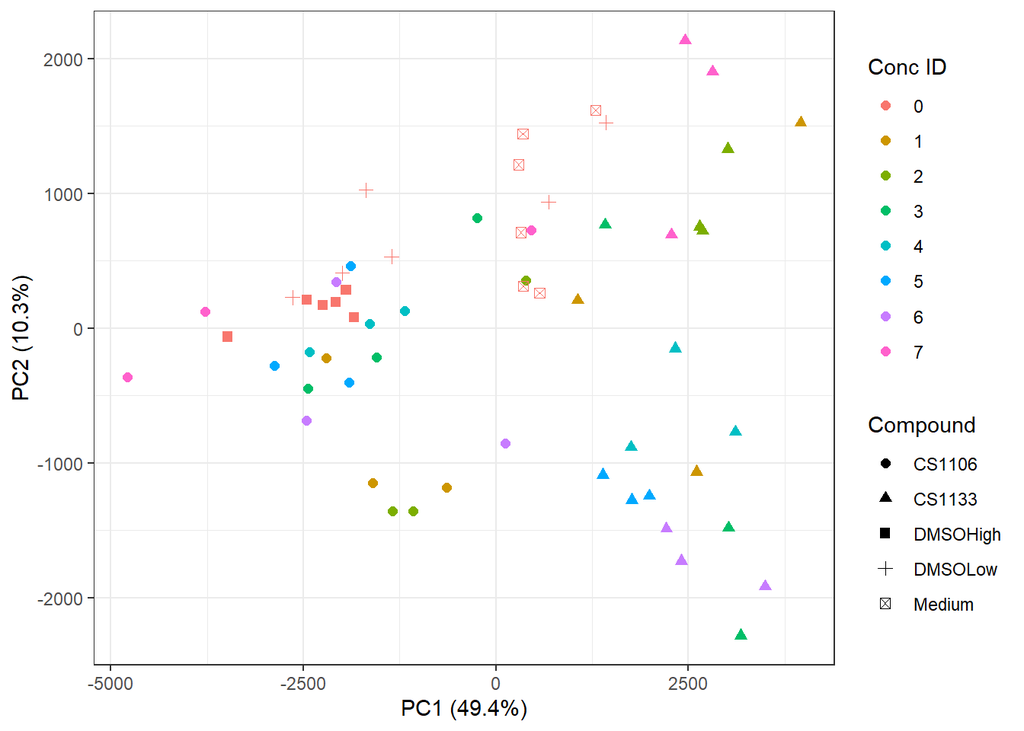

```r
metaData %>%
  # Convert concentration ID to a factor
  mutate(conc_ID = factor(conc_ID)) %>%
  # Plot PC1 against PC2
  ggplot(aes(x = PC1, y = PC2,
             shape = compound_ID, color = conc_ID)) +
  geom_point(size = 2) +
  labs(x = paste0("PC1 (", round(100*var_explained[1,2], 2), "%)"),
       y = paste0("PC2 (", round(100*var_explained[2,2], 2), "%)"),
       color = "Conc ID", shape = "Compound") +
  theme_bw()
```

```r
#gene_name_from_pca (<chr> for character): This column contains the identifiers for your genes. These names come from the row names of your logcpmData_for_pca after it was transposed (so they were originally column names of t(logcpmData_for_pca))
#PC1 (<dbl> for double/numeric):This column shows the loading score for each gene on PC1.
#abs_loading (<dbl> for double/numeric):This column shows the absolute value of the PC1 loading score

# The genes listed at the top of this table are the ones whose expression patterns are most strongly associated with the variation explained by PC1.
```

[output not shown]

# 4 Session Info

**Exercise 12: Print your session info at the end of the script, knit the R markdown document, and push it to GitHub:**

```r
library(sessioninfo)
```

[output not shown]

That is the end of the entire QC pipeline. Example answers will be available from the `BOO_template` GitHub on Tuesday.